# Comparing Percentages Between Groups

Three is a crowd…

P. Lombardo

## Loading packages, etc.

```r
library(tidyverse)
library(patchwork)
library(DescTools)
library(broom)
gss<-read.csv('data/gss.csv',header = T, stringsAsFactors = T)
movies<-read.csv('data/movies.csv',header = T, stringsAsFactors = T)
```

In previous lessons, we explored how to compare population means between two different groups using either hypothesis testing or confidence intervals. In this lesson, we’ll focus on comparing population percentages between two populations.

There are just a few main differences:

1. Our testing assumptions are different, so we need to keep that in mind.
2. We will use `prop.test()` for hypothesis testing.
   - *Note*: As with hypothesis tests of single percentages, we will first summarize our data in a `table()`, and then plug in values. (There is a more streamlined way, but this way provides more flexibility in the questions we can ask.)

### A hypothesis test

**Let’s test a saucy claim my father once made: from the year 2000 forward, having a college degree has an association with one’s political party identification.** We will set a null hypothesis that whether you are democrat or other, the percentage of college degrees is the same.

What does the General Social Survey data, `gss`, suggest?

```r
#place code here.
gss %>% head()
```

|  | year | age | sex | college | partyid | hompop | hours | income | class | finrela | weight |
| --- | --- | --- | --- | --- | --- | --- | --- | --- | --- | --- | --- |
| 1 | 2014 | 36 | male | degree | ind | 3 | 50 | $25000 or more | middle class | below average | 0.8960034 |
| 2 | 1994 | 34 | female | no degree | rep | 4 | 31 | $20000 - 24999 | working class | below average | 1.0825000 |
| 3 | 1998 | 24 | male | degree | ind | 1 | 40 | $25000 or more | working class | below average | 0.5501000 |
| 4 | 1996 | 42 | male | no degree | ind | 4 | 40 | $25000 or more | working class | above average | 1.0864000 |
| 5 | 1994 | 31 | male | degree | rep | 2 | 40 | $25000 or more | middle class | above average | 1.0825000 |
| 6 | 1996 | 32 | female | no degree | rep | 4 | 53 | $25000 or more | middle class | average | 1.0864000 |

0. Prepare the data

Let’s consider only the information from collected from participants in the year 2000 and later. And let’s create a new variable called `is_dem` that records whether a person’s political party identification is “democrat” or “other”.

```r
#place code here to prepare the data frame.
gss %>%
    filter(year >=2000) %>%
    mutate(is_dem = ifelse(partyid=="dem","democrat","other")) %>%
    select(year, is_dem, college) -> gss1
```

1. Who is group 1? Let’s run a levels command to see which comes first.

```r
#place code here.
levels(gss1$is_dem)
```

```r
class(gss1$is_dem)
```

```
## [1] "character"
```

```r
# comes back as NULL because it's not a "factor" variable
```

If you get NULL, revert to our other signs: alphabetical order, summarise and see what group comes in the first row, plot and see what group get’s listed first.

These will all point to “democrat” as group 1.

*What difference are we making a claim about? (Make the order clear.)*

p1: population percentage of democrats that have a college degree p2: population percentage of “other” (Rep and Ind.) that have a college degree.

We are claiming p1 - p2 is not equal to zero.

*What are the Null and Alternative Hypotheses?*

- $H_0: p_1 - p_2 = 0$
- $H_1: p_1 - p_2 \neq 0$

*What type of test is this? How should we set `alternative = ...`*

Two-tailed test, using `alternative = "two.sided"` in our command.

Let’s summarize and visualize:

```r
# summary table:
gss1 %>%
    select(is_dem, college) %>%
    table() %>%
    prop.table(margin = 1)
```

```
##           college
## is_dem        degree no degree
##   democrat 0.4000000 0.6000000
##   other    0.4666667 0.5333333
```

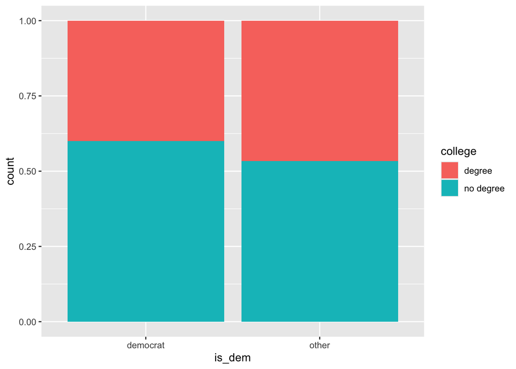

```r
ggplot(data = gss1,
       aes(x = is_dem, fill = college))+
    geom_bar(position="fill")
```

```r
# show code for switching the levels
```

*On the sample,* it appears that “other” (Republicans and Independents) have a higher sample percentage of degree holders than democrats.

2. Do we meet the requirements of this test?

Assuming the null hypothesis will require $p_1 = p_2$, so we will check our usual *10-successes-and-10-failures* criteria on a “pooled” sample percentage. (*Note*: some texts just have you check the success-failure condition on each group; this is probably fine too.)

- The pooled sample percentage of “degree” holders combines the data from both the “democrat” and “other” groups.

```r
#Let's look at a table of results
gss1 %>%
    select(college) %>%
    table() %>% addmargins()
```

```
## college
##    degree no degree       Sum
##        85       105       190
```

```r
gss1 %>%
    select(is_dem, college) %>%
    table() %>% addmargins()
```

```
##           college
## is_dem     degree no degree Sum
##   democrat     22        33  55
##   other        63        72 135
##   Sum          85       105 190
```

We need at least 10 “degree” and at least 10 “no-degree” to run this test. (When we assume p1 = p2, we get to pool (or combine) our explanatory variable groups and just consider the counts for the response variables.) We satisfy these conditions with 85 degree holders and 105 no-degree holders.

3. Let’s write the shortcut code!

Guidelines:

- The `x` argument contains the counts for each group for the category of interest. To match the ordering for the `levels()` command, list the counts for the top row group first. For example, since “democrat” is our group 1, we would use `x = c(22, 63)`.
- the `n` argument contains the sample sizes for our groups. Again, order is important here, and you should start with the sample size for the top row: `n = c(55,135)`
- The only other argument we have to set is `alternative = ...`, which depends on our type of test: two-tailed test.

```r
#place code here.
gss1 %>%
    select(is_dem, college) %>%
    table() %>% addmargins()
```

```
##           college
## is_dem     degree no degree Sum
##   democrat     22        33  55
##   other        63        72 135
##   Sum          85       105 190
```

```r
prop.test(x = c(22, 63),
          n = c(55, 135),
          alternative = "two.sided" # could leave this empty as its the default entry
          ) %>% tidy() %>%
    select(p.value)
```

| p.value |
| --- |
| 0.4982123 |

4. Conclusion? What can I tell my Dad?

My $P$-value (0.498) is well above any reasonable significance level (let’s use 0.05), so we have failed to provide evidence against the claim that the percentage of degree holders is equal among democrats and others.

**Important Notes:**

- Note that we compare the percentage of degree holders. If we wanted to compare the percentage without a degree (the second column category of our table output), we would use `x = c(33,72)`.
- We can also use the `x` and `n` arguments to change who is “group 1”. For example, if we wanted to use the “other” group as group 1, we would use `x = c(63,22)` and `n = c(135,55)`.
- We can look at left and right-tailed tests too by adjusting the `alternative` argument For example, if my Dad was more brazen and claimed that democrats have an equal or lower percentage of college degrees when compared to others, we’d have
  - $H_0: p_{\text{dem}} - p_{\text{other}} \leq 0$
  - $H_1: p_{\text{dem}} - p_{\text{other}} >0$
  - `alternative = "greater"`

## Movies

In the `movies` data frame, we have a random sample of movies over many years. Take a minute to explore the variables and the data frame:

```r
#place code here
str(movies)
```

```
## 'data.frame':    700 obs. of  8 variables:
##  $ title      : Factor w/ 698 levels "10","10 Cloverfield Lane",..: 524 125 318 411 583 204 101 89 659 291 ...
##  $ year       : int  2007 2009 2000 1970 2012 2010 1989 2022 2005 2006 ...
##  $ runtime    : int  126 100 114 113 103 115 113 127 132 107 ...
##  $ certificate: Factor w/ 12 levels "","Approved",..: 9 8 8 3 9 10 10 10 10 9 ...
##  $ rating     : num  7.5 7.7 5.7 7.5 7.9 6.8 7.1 7.3 8.2 5.3 ...
##  $ gross      : num  30.2 75.3 60.9 3.7 17.7 ...
##  $ IsDrama    : Factor w/ 2 levels "No","Yes": 2 2 1 2 2 2 2 1 2 2 ...
##  $ IsComedy   : Factor w/ 2 levels "No","Yes": 1 1 1 1 1 1 1 2 1 2 ...
```

#### To laugh or not to laugh

Let’s test the following claim:

> From the year 2000 forward and among movies rated “R” and “PG-13”, the percentage of comedies making over 100 million is greater than or equal to the percentage of other genre movies makeing over 100 million.
0. Prepare the data

Create a new data frame by doing the following:

- Filter `movies` to include only movies from the year 2000 forward, and only those with a certificate rating of “R” or “PG-13”.
- Add a variable called **over_100** that records whether a movie grossed more that 100. (The **gross** variable is measured in millions, so this is really 100 million.)

```r
#place code here to prepare the data frame.
movies %>%
    filter(year >= 2000,
           certificate %in% c("R","PG-13")) %>%
    mutate(over_100 = ifelse(gross > 100, "Yes","No")) %>%
    select(IsComedy, over_100) -> movies1
```

1. Who is group 1? Let’s run a levels command to see which comes first by default.

```r
#place code here.
levels(movies$IsComedy)
```

```
## [1] "No"  "Yes"
```

*What difference are we making a claim about? (Make the order clear.)*

p1: percentage of non-comedies that make over 100 mill p2: percenage of comedies that make over 100 mill

We are claiming that p1 - p2 <= 0 (Comedies, p2, are supposed to be bigger in the original claim. )

*What are the Null and Alternative Hypotheses?*

- $H_0: p1 - p2<= 0$
- $H_1: p1 - p2 > 0$

*What type of test is this? How should we set `alternative = ...`*

Type of test: right-tailed `alternative = "greater"`

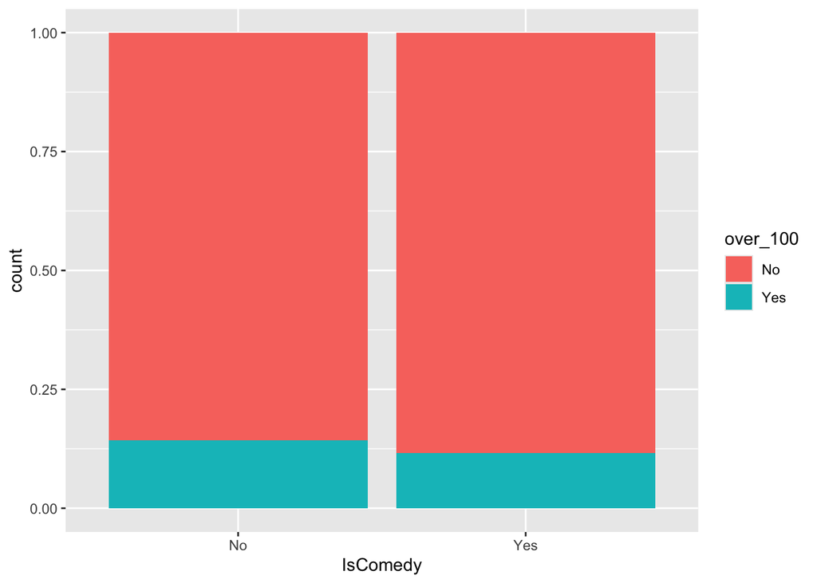

```r
ggplot(data = movies1,
       aes(x = IsComedy, fill = over_100))+
    geom_bar(position = "fill")
```

2. Do we meet the requirements of this test?

Remember for the hypothesis test, we only need to satisfy the 10-yes-10-no criteria in the *pooled sample*. Do we have at least 10 movies that grossed over 100 million and at least 10 that didn’t?

```r
#Let's look at a table of results
movies1 %>% select(over_100) %>% table() %>% addmargins()
```

```
## over_100
##  No Yes Sum
## 310  48 358
```

We have at least 10 movies making more than 100 mill, and at least 10 that didn’t. We satisfy our assumptions.

3. Write the shortcut code. Remember to be careful of the order in which you put the values in the `x` and `n` arguments. Do these counts/sample-sizes go in the same order as your hypotheses above?

```r
# summarise first
movies1 %>%
    select(IsComedy, over_100) %>%
    table() %>% addmargins()
```

```
##         over_100
## IsComedy  No Yes Sum
##      No  203  34 237
##      Yes 107  14 121
##      Sum 310  48 358
```

```r
#place code here.
prop.test(
    # remember non-comedy is group 1 for the way we
    # wrote our hypotheses...
    x = c(34, 14),
    n = c(237, 121),
    alternative = "greater"
) %>% tidy() %>%
    select(p.value)
```

| p.value |
| --- |
| 0.2859883 |

4. Conclusion: At a significance level of 0.05, we failed to reject the null hypothesis that comedies have a greater or equal percentage of movies making more than 100 million when compared to other genres.  
   (Reminder, this applies to year >= 2000 and only R and PG-13 movies.)

### Further practice

Test the following similar claim:

> From the year 2000 forward and among movies rated “R” and “PG-13”, the percentage of dramas making more than 100 million is greater than or equal to the percentage of “other” genre movies that made more than 100 million.

Show your work below, moving through the usual steps for hypothesis testing.

0. Prepare the data:

```r
#place code here to prepare the data frame.
movies %>%
    filter(year >= 2000,
           certificate %in% c("R","PG-13")) %>%
    mutate(over_100 = ifelse(gross > 100, "Yes","No")) %>%
    select(IsDrama, over_100) -> movies2
```

1. Who is group 1? Let’s run a levels command to see which comes first by default.

```r
#place code here.
levels(movies$IsDrama)
```

```
## [1] "No"  "Yes"
```

*What difference are we making a claim about? (Make the order clear.)*

p1: percentage of non-dramas that make over 100 mill p2: percenage of dramas that make over 100 mill

We are claiming that p1 - p2 <= 0 (Dramas, p2, are supposed to be greater in the original claim we want to reject. )

*What are the Null and Alternative Hypotheses?*

- $H_0: p_1 - p_2 \leq 0$
- $H_1: p_1 - p_2 > 0$

*What type of test is this? How should we set `alternative = ...`*

Type of test: right-tailed `alternative = "greater"`

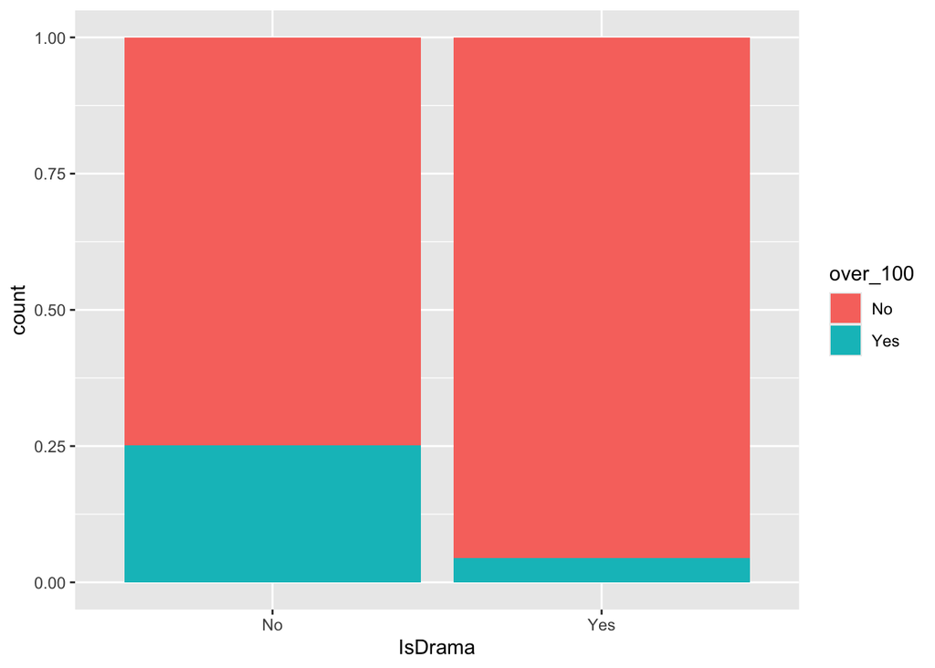

```r
ggplot(data = movies2,
       aes(x = IsDrama, fill = over_100))+
    geom_bar(position = "fill")
```

2. Do we meet the requirements of this test?

Remember for the hypothesis test, we only need to satisfy the 10-yes-10-no criteria in the *pooled sample*. Do we have at least 10 movies that grossed over 100 million and at least 10 that didn’t?

```r
#Let's look at a table of results
movies2 %>% select(over_100) %>% table() %>% addmargins()
```

```
## over_100
##  No Yes Sum
## 310  48 358
```

We have at least 10 movies making more than 100 mill, and at least 10 that didn’t. We satisfy our assumptions.

3. Write the shortcut code. Remember to be careful of the order in which you put the values in the `x` and `n` arguments. Do these counts/sample-sizes go in the same order as your hypotheses above?

```r
# summarise first
movies2 %>%
    select(IsDrama, over_100) %>%
    table() %>% addmargins()
```

```
##        over_100
## IsDrama  No Yes Sum
##     No  116  39 155
##     Yes 194   9 203
##     Sum 310  48 358
```

```r
#place code here.
prop.test(
    # remember non-comedy is group 1 for the way we
    # wrote our hypotheses...
    x = c(39, 9),
    n = c(155, 203),
    alternative = "greater"
) %>% tidy() %>%
    select(p.value)
```

| p.value |
| --- |
| 1.457024e-08 |

4. Conclusion: At a significance level of 0.05, we have sufficient evidence to suggest that the percentage of dramas making over 100 mill is *less than* the same percentage for other genres.